# Assignment2

Andy Cox

19 May 2016

# Health and Economic Impact of Storm Events in the US

## Synopsis

The analysis on the storm event database revealed that tornadoes are the most dangerous weather events, casusinf the most numbers of injuries and fatalities. The economic impact of weather events was also analyzed. The largest number of property damages are casued by tornadoes, whilst the largest crop damage is casued by hail.

## Introduction

Storms and other severe weather events can cause both public health and economic problems for communities and municipalities. Many severe events can result in fatalities, injuries, and property damage, and preventing such outcomes to the extent possible is a key concern.

This project involves exploring the U.S. National Oceanic and Atmospheric Administration’s (NOAA) storm database. This database tracks characteristics of major storms and weather events in the United States, including when and where they occur, as well as estimates of any fatalities, injuries, and property damage.

Storm Database data, documentation are available at

[Storm Events Database](http://www.ncdc.noaa.gov/stormevents/ftp.jsp), provided by The data is from a comma-separated-value file available [here](https://d396qusza40orc.cloudfront.net/repdata%2Fdata%2FStormData.csv.bz2).

There is also some documentation of the data [here](https://d396qusza40orc.cloudfront.net/repdata%2Fpeer2_doc%2Fpd01016005curr.pdf).

## Objectives

Across the United States, which types of events are most harmful with respect to population health?

Across the United States, which types of events have the greatest economic consequences?

## Data Processing

The working environment is cleared and required packages are loaded.

```r
rm(list = ls())
library(ggplot2)
library(gridExtra)
library(plyr)
library(stringr)
```

```r
stormdat1 <- read.csv(bzfile("repdata-data-StormData.csv.bz2"))
#Select only the columns we need
cols <- c("BGN_DATE","EVTYPE", "FATALITIES", "INJURIES", "PROPDMG", "PROPDMGEXP", "CROPDMG", "CROPDMGEXP")
stormdat1<-stormdat1[,colnames(stormdat1)%in%cols]
```

**Justification for Data Transformations** Before the analysis, the data need some preprocessing. Event types have over 900 levels and those levels don’t have a specific and clear format. For instance, there are events with many variations in naming conventions. Intial Inspection shows alot of work is needed to correct this. However, as this assigment is about reproducible research and not data analysis, only a minimum will be done to transfrom the data

```r
# number of unique event types
length(unique(stormdat1$EVTYPE))
```

```
## [1] 985
```

```r
 event_types <- stormdat1$EVTYPE
# translate all letters to uppercase
event_types <- toupper(str_trim(event_types))
event_types <- gsub("TSTM WIND", "MARINE THUNDERSTORM WIND" , event_types)
event_types <- gsub("URBAN/SML STREAM FLD", "HEAVY RAIN", event_types)
event_types <- gsub("MARINE TSTM WIND","MARINE THUNDERSTORM WIND", event_types)
event_types <- gsub("WILD/FOREST FIRE", "WILDFIRE", event_types)
event_types <- gsub("marinethunderstormwind/hail", "marinethunderstormwind", event_types)
event_types <- gsub("TSTM WIND/HAIL","MARINE THUNDERSTORM WIND", event_types)
event_types <- gsub("flashflooding", "flashflood", event_types)
event_types <- gsub("FLOOD/FLASH FLOOD", "FLASH FLOOD", event_types)
event_types <- gsub("WINTER data/MIX", "WINTER data", event_types)
event_types <- gsub("RIP CURRENTS", "RIP CURRENT", event_types)
event_types <- gsub("DENSEDENSEFOG", "DENSE FOG", event_types)
event_types <- gsub("STRONG WINDS","ASTROMICAL LOW TIDE", event_types)
event_types <- gsub("COASTAL FLOODING", "COASTAL FLOOD ", event_types)
event_types <- gsub("RIVER FLOOD", "FLOOD", event_types)
event_types <- gsub("RECORD WARMTH", "HEAT", event_types)
event_types <- gsub("RECORD HEAT", "HEAT", event_types)
event_types <- gsub("FREEZE", "FROST/FREEZE", event_types)
event_types <- gsub("HEATWAVE", "EXCESSIVE HEAT", event_types)
event_types <- gsub("HURRICANE/TYPHOON", "HURRICANE", event_types)

# replace all punct. characters with a space
# update the data frame
stormdat1$EVTYPE <- event_types
```

# Results

## Dangerous Events with respect to Population Health

To find the event types that are most harmful to population health, the number of casualties and injuries are aggregated by the event type.

```r
fatalities <- ddply(stormdat1, .(EVTYPE), summarize,
                    fatalities = sum(FATALITIES),
                    injuries = sum(INJURIES))

# Find events that caused most death and injury
fatal_events <- head(fatalities[order(fatalities$fatalities, decreasing = T), ], 10)
fatal_events<-fatal_events[, c("EVTYPE", "fatalities")]
fatal_events
```

```
##                       EVTYPE fatalities
## 760                  TORNADO       5633
## 109           EXCESSIVE HEAT       1903
## 131              FLASH FLOOD        995
## 234                     HEAT        939
## 409                LIGHTNING        816
## 530              RIP CURRENT        572
## 435 MARINE THUNDERSTORM WIND        514
## 147                    FLOOD        472
## 312                HIGH WIND        248
## 12                 AVALANCHE        224
```

```r
injury_events <- head(fatalities[order(fatalities$injuries, decreasing = T), ], 10)
injury_events<-injury_events[, c("EVTYPE", "injuries")]
injury_events
```

```
##                       EVTYPE injuries
## 760                  TORNADO    91346
## 435 MARINE THUNDERSTORM WIND     6983
## 147                    FLOOD     6791
## 109           EXCESSIVE HEAT     6525
## 409                LIGHTNING     5230
## 234                     HEAT     2150
## 378                ICE STORM     1975
## 131              FLASH FLOOD     1792
## 687        THUNDERSTORM WIND     1488
## 854                 WILDFIRE     1456
```

Top 10 events that caused largest number of deaths are

**Figure 1.** Barplot showing the frequencies of fatalities due to specific weather events.

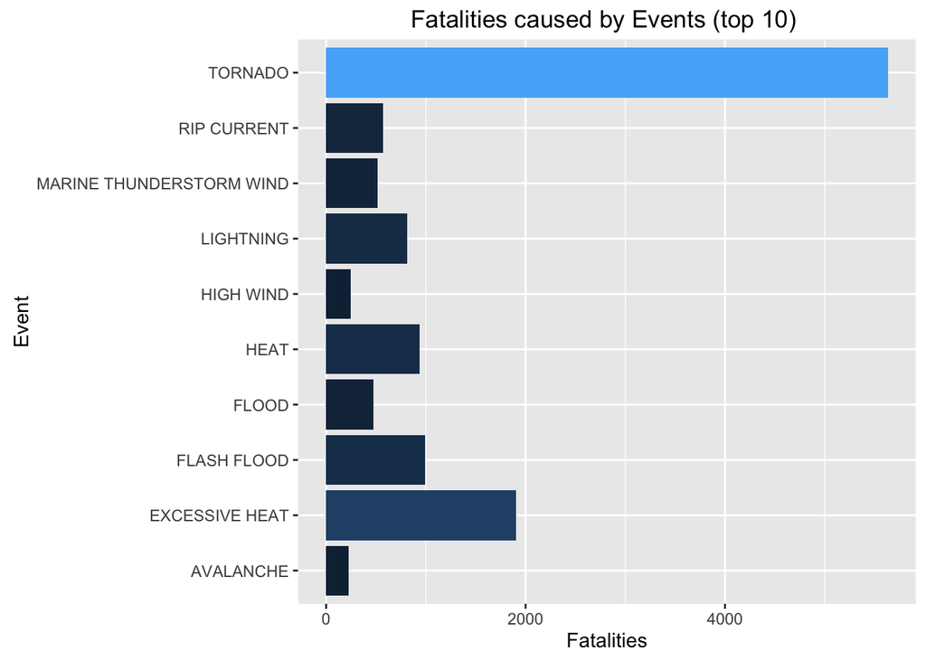

**Figure 2.** Barplot showing the frequencies of injuries due to specific weather events.

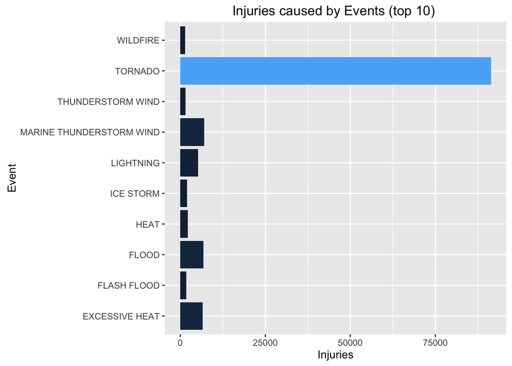

```r
econ_loss <- ddply(stormdat1, .(EVTYPE), summarize,
                    property = sum(PROPDMG),
                    crop = sum(CROPDMG))

# Find events that caused most death and injury
prop_events <- head(econ_loss[order(econ_loss$property, decreasing = T), ], 10)
prop_events<-prop_events[, c("EVTYPE", "property")]
prop_events
```

```
##                       EVTYPE  property
## 760                  TORNADO 3212258.2
## 131              FLASH FLOOD 1439327.8
## 435 MARINE THUNDERSTORM WIND 1336540.0
## 147                    FLOOD  913794.2
## 687        THUNDERSTORM WIND  876844.2
## 203                     HAIL  688693.4
## 409                LIGHTNING  603351.8
## 713       THUNDERSTORM WINDS  446293.2
## 312                HIGH WIND  324731.6
## 867             WINTER STORM  132720.6
```

```r
crop_events <- head(econ_loss[order(econ_loss$crop, decreasing = T), ], 10)
crop_events<-crop_events[, c("EVTYPE", "crop")]
crop_events
```

```
##                       EVTYPE      crop
## 203                     HAIL 579596.28
## 131              FLASH FLOOD 180628.16
## 147                    FLOOD 171527.88
## 435 MARINE THUNDERSTORM WIND 109252.60
## 760                  TORNADO 100018.52
## 687        THUNDERSTORM WIND  66791.45
## 77                   DROUGHT  33898.62
## 713       THUNDERSTORM WINDS  18684.93
## 312                HIGH WIND  17283.21
## 245               HEAVY RAIN  13916.60
```

**Figure 3.** Barplot showing the economic losses due to property related events

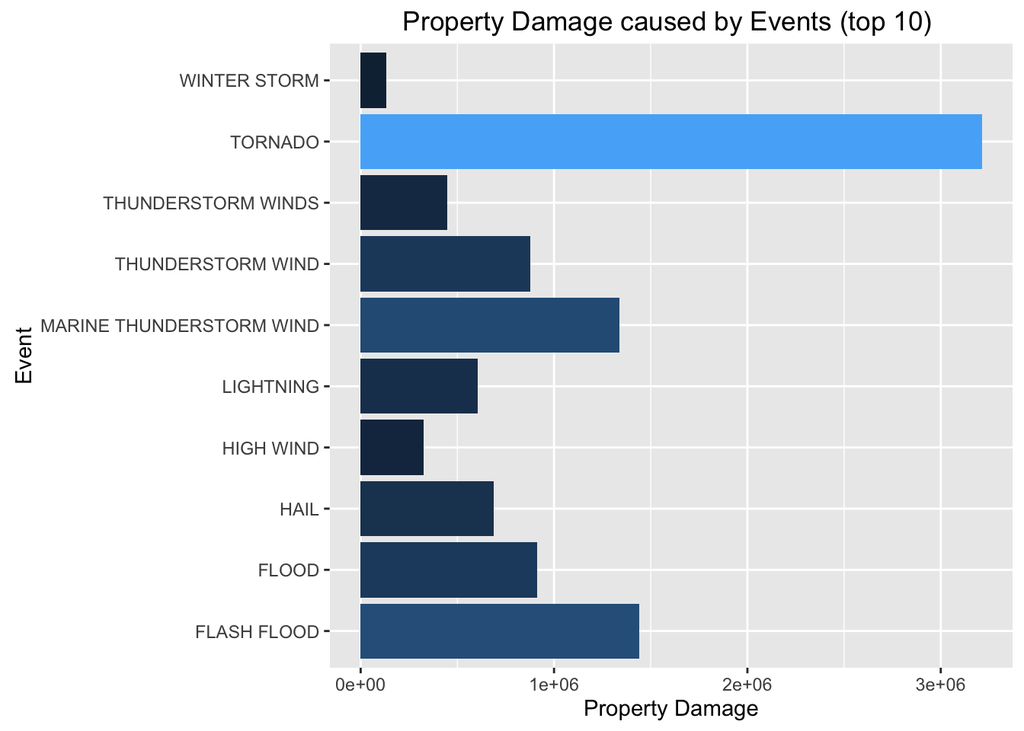

# Conclusions

The weather condition that, by a large margin, causes the most fatalities and injuries are Tornados. Tornado’s also cause the most proporty damages, whilst most crop damages are casued by hail.